# NB Pipeline explanatory notebooks

## Notebook 1: Exploratory Data Analysis

The aim of this series of notebooks is to explain the functionality of the Negative Bionomial model piepline and explain justify the different desing choices made. In this first notebook we will perform exoloratory data anlysis of both the donor and patient data and perform a number of Quality Control (QC) steps to clean the datasets for further usage.

## 1.1 What does the data contain?

Each row is one clonotype in one sample:

- `count` — reads assigned to the clonotype. The data are **RNA**-based, so a read count does not map one-to-one to the number of cells detected (as opposed to **DNA** sampling), but rather how many TCR transcripts the clonotype has. One cell may provide several TCR transcripts.
- `freq` - the clone's share of the sample's in-frame reads (in %).
- `D_t` - the sample's in-frame depth.

The data frames we will use from now on have already been procesed to only use In-Frame clonotypes and anonymized.

#### Structure of the processed data

The data is stored in *subjects*_clono where *subjects* is either donors or patients. The structure of the folder is as following:

```
subjects_clono/
├── counts/
│   ├── subject_1.csv
│   ├── subject_2.csv
│   └── ...
├── sequences/
│   ├── subject_1_sequences.csv
|   ├── subject_2_sequences.csv
│   └── ...
├── subjects.txt
├── sample_sizes.csv
└── README.md
```

`subjects.txt` contains the names of all the subjects present in the folder.

Each clone gets identified by the key [`CDR3_sequence`, `TRBV`,`TRBJ`] and gets assinged a clone identifier (`1`, `2`, …) in order or appearance. Clone identifiers (`1`, `2`, …) are assigned **per person**. The same identifier in two people is not the same clone. The mapping of keys->identifiers per subject are found in the sequences folder.

The `counts/` folder contains the data frame with the counts per anonymized clonotype.

`sample_sizes.csv` contains the sample size per subject and day.

In `data_io.py` we provide a series of helper functions to easily load the dataframes, either per donor/patient or all donors together, with several options to choose which columns to load to not overload memory. **The helpers only help this specific saving format**

|  | patient | day | clono | count | D_t | freq |
| --- | --- | --- | --- | --- | --- | --- |
| 0 | HD106_SEQTR | 0 | 1 | 226089 | 21258772 | 0.010635 |
| 1 | HD106_SEQTR | 0 | 2 | 159926 | 21258772 | 0.007523 |
| 2 | HD106_SEQTR | 0 | 3 | 141200 | 21258772 | 0.006642 |
| 3 | HD106_SEQTR | 0 | 4 | 82582 | 21258772 | 0.003885 |
| 4 | HD106_SEQTR | 0 | 5 | 70402 | 21258772 | 0.003312 |

| patient | n_samples | days | depth_M | clones_k | top_clone |
| --- | --- | --- | --- | --- | --- |
| HD106_SEQTR | 4 | 0, 46, 82, 131 | 13.5–21.3 | 794.9–1162 | 0.009–0.012 |
| HD197_SEQTR | 4 | 0, 46, 82, 131 | 15.5–18.3 | 926.2–1130 | 0.006–0.011 |
| HDBR01_SEQTR_ReSeq | 4 | 0, 21, 42, 126 | 10.4–21.7 | 420.2–660 | 0.003–0.003 |
| HDBR02_SEQTR_ReSeq | 3 | 0, 48, 71 | 5.5–9.0 | 219.9–353 | 0.154–0.252 |
| HDBR03_SEQTR_ReSeq | 5 | 0, 21, 35, 66, 84 | 5.1–10.8 | 311.6–453 | 0.016–0.039 |
| HDBR06_SEQTR_ReSeq | 4 | 0, 21, 82, 105 | 5.1–11.7 | 6.7–438 | 0.035–0.242 |

```
['HD106_SEQTR',
 'HD197_SEQTR',
 'HDBR01_SEQTR_ReSeq',
 'HDBR02_SEQTR_ReSeq',
 'HDBR03_SEQTR_ReSeq',
 'HDBR06_SEQTR_ReSeq']
```

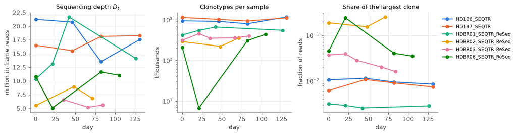

From this table and figures, we can notice several features worth mentioning:

```
HD106_SEQTR 0 | clonotypes: 938259 | with count > K: 86192 | singletons: 482715
HDBR03_SEQTR_ReSeq 21 | clonotypes: 452593 | with count > K: 10249 | singletons: 204318
```

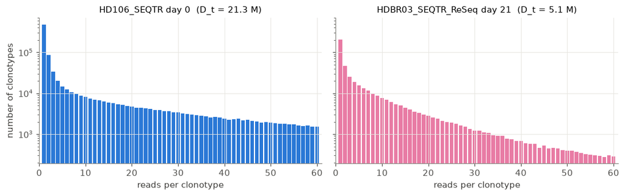

- 1. Observed counts are conditional on detection. Clones with expected count near 1 are reported only when they fluctuate upwards. Fitting the noise on detected counts uses the zero-truncated NB, $P(X = x \mid X \ge 1) = f(x)/(1 - f(0))$, where a higher truncation point $c \ge 1$ can be used to exclude the low-count range dominated by error variants.
- 2. A missing clone is an NB zero. It contributes $P(X = 0 \mid \mu, \phi)$ with $\mu = D_t f$, so the same clone at the same frequency is more likely to be missing in a shallow sample than in a deep one. The depth dependence enters through $D_t$, not through a sample-specific threshold.

## 1.2 Dropouts

Dropouts/Nans/Non-detections are an essential part of modeling the trajectories. In the following cells, we will better understand the nature and frequency of dropouts in the datasets.

|  | patient | n_timepoints | n_clonotypes | n_missing | n_clono | pct_clono |
| --- | --- | --- | --- | --- | --- | --- |
| 0 | HD106_SEQTR | 4 | 3551504 | 0 | 24641 | 0.69 |
| 1 | HD106_SEQTR | 4 | 3551504 | 1 | 35893 | 1.01 |
| 2 | HD106_SEQTR | 4 | 3551504 | 2 | 106705 | 3.00 |
| 3 | HD106_SEQTR | 4 | 3551504 | 3 | 3384265 | 95.29 |
| 4 | HD197_SEQTR | 4 | 3816358 | 0 | 40111 | 1.05 |

|  | patient | n_timepoints | n_clonotypes | n_missing | n_clono | pct_clono |
| --- | --- | --- | --- | --- | --- | --- |
| 0 | BR032 | 6 | 3144106 | 0 | 21 | 0.00 |
| 1 | BR032 | 6 | 3144106 | 1 | 4970 | 0.16 |
| 2 | BR032 | 6 | 3144106 | 2 | 8687 | 0.28 |
| 3 | BR032 | 6 | 3144106 | 3 | 18898 | 0.60 |
| 4 | BR032 | 6 | 3144106 | 4 | 69932 | 2.22 |

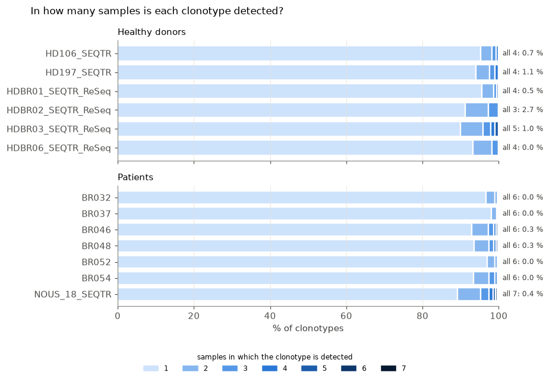

## 1.3 Clone-Size distribution

The next step to understand the composition of the data, is to study the frequency distribution of the clones.

| patient | freq | clones | reads |
| --- | --- | --- | --- |
| HD106_SEQTR | 1e-6 – 1e-5 | 0.987038 | 0.643333 |
|  | 1e-5 – 1e-4 | 0.012646 | 0.236242 |
|  | ≥ 1e-4 | 0.000317 | 0.120425 |
| HD197_SEQTR | 1e-6 – 1e-5 | 0.990254 | 0.636473 |
|  | 1e-5 – 1e-4 | 0.009315 | 0.206925 |
|  | ≥ 1e-4 | 0.000431 | 0.156601 |
| HDBR01_SEQTR_ReSeq | 1e-6 – 1e-5 | 0.951092 | 0.404855 |
|  | 1e-5 – 1e-4 | 0.048393 | 0.537028 |
|  | ≥ 1e-4 | 0.000515 | 0.058116 |
| HDBR02_SEQTR_ReSeq | 1e-6 – 1e-5 | 0.960176 | 0.258915 |
|  | 1e-5 – 1e-4 | 0.038248 | 0.254723 |
|  | ≥ 1e-4 | 0.001576 | 0.486362 |
| HDBR03_SEQTR_ReSeq | 1e-6 – 1e-5 | 0.950473 | 0.358453 |
|  | 1e-5 – 1e-4 | 0.047981 | 0.408646 |
|  | ≥ 1e-4 | 0.001546 | 0.232901 |
| HDBR06_SEQTR_ReSeq | 1e-6 – 1e-5 | 0.939957 | 0.190154 |
|  | 1e-5 – 1e-4 | 0.058039 | 0.381095 |
|  | ≥ 1e-4 | 0.002004 | 0.428751 |

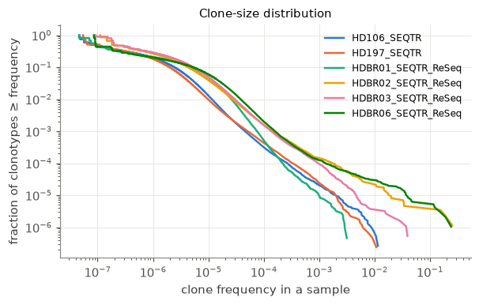

**What this shows.** The repertoire is extremely heavy-tailed. Most clones have low frequency however they take up a relatively small percentage of the total read count. As such, it could be reasonable to indtroduc a frequency cutoff for both the computation of the overdispersion and the tested patient trajectories. The implementation of said cutoff and its value will be studied in further notebooks using simulated data.

## 1.4 Sample QC: which samples are failed libraries?

One crucial step before performing infernce is filtering out failed samples which contaminate and bias the results. This step is knows as Quality Control (QC). We filter based on different metric for which we set arbitrary thresholds.

Section 1.1 showed that donors differ by an order of magnitude in diversity and clonality, so absolute thresholds would flag whole people. Each metric is instead expressed **relative to the median of the same person's other samples** (`*_rel` = 1 means typical for that person):

| metric | what a failed library looks like | fails if |
| --- | --- | --- |
| `n_clones_rel` — clonotypes reported | to few clonotypes | < 0.2 |
| `top_share_rel` — share of the largest clone | one clone dominates PCR reads | > 5 |
| `reads_per_clone_rel` — reads / clonotype | reads spread over few clones (library size aware version of `n_clones_rel`) | > 5 |

Anchor clones: detected in **all** the person's other samples with mean frequency ≥ 1e-5. A sample is **dropped if it fails at least two** criteria; a single failure is flagged for review but kept.

| cohort | patient | day | failed on | n_clones_rel | top_share_rel | reads_per_clone_rel | n_fails | drop | review |
| --- | --- | --- | --- | --- | --- | --- | --- | --- | --- |
| donor | HDBR06_SEQTR_ReSeq | 21 | n_clones, top_share, reads_per_clone | 0.022 | 5.974 | 19.832 | 3 | True | False |
| patient | BR037 | 28 | top_share | 1.138 | 12.149 | 0.583 | 1 | False | True |
| patient | BR046 | 120 | top_share | 0.734 | 6.688 | 1.520 | 1 | False | True |
| patient | BR052 | 164 | n_clones, reads_per_clone | 0.048 | 1.128 | 10.355 | 2 | True | False |
| patient | BR052 | 192 | n_clones, reads_per_clone | 0.100 | 0.808 | 5.620 | 2 | True | False |
| patient | BR054 | 141 | top_share | 0.264 | 7.813 | 2.069 | 1 | False | True |

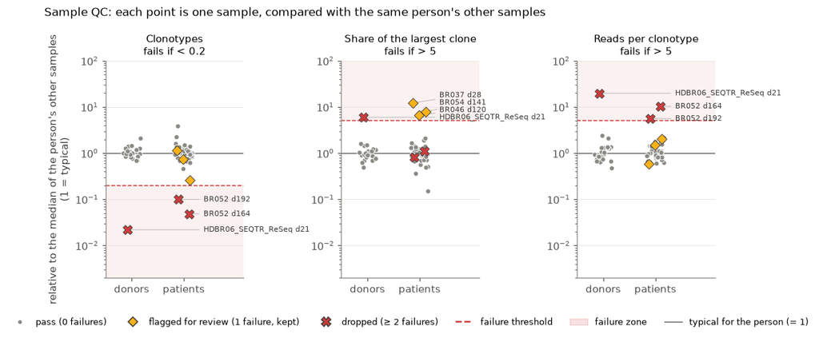

**What this shows.**

There is geniune criticism to be made about the selected metrics used for QC, and the cirterias for flagging failed libraries could and should be revised in the future, potentially supported by further data. As it stands, we correctly flag **HDBR06 day 21** as a failed library, which we expected to fail under other considerable metrics. This is the most imporant drop, as donors are used for the Null-Calibration and directly influence the tests performed on the patient trajectories.

Patient **BR052** had two dropped libraries, however, the results of one patient do not influence those of another, so these libraries can be flagged instead of dropped and still be anaylsed downstream, with careful monitoring of the results.

# 1.5 Mean–Variance Relationship

A crucial step for choosing a count model is to determine the mean–variance relationship of the data. Under a Poisson model, all count noise comes from pure read sampling, so the variance equals the mean:

$$X_{ct} \sim \text{Poisson}(\mu_{ct}), \qquad \operatorname{Var}(X_{ct}) = \mu_{ct}.$$

As the plots below show, the data do not follow this: the variance grows faster than the mean, i.e. the counts are **overdispersed**. Clones fluctuate between samples for reasons beyond read sampling: which cells happen to be in the blood draw, how many TCR transcripts each cell carries (the data are RNA-based), and library preparation. We therefore model the counts with a **negative binomial** (NB), which adds a quadratic variance term controlled by a dispersion parameter $\phi$:

$$X_{ct} \sim \text{NB}(\mu_{ct}, \phi), \qquad \mathbb{E}[X_{ct}] = \mu_{ct}, \qquad \operatorname{Var}(X_{ct}) = \mu_{ct} + \frac{\mu_{ct}^2}{\phi}.$$

Here $\phi$ is the NB *size*: a **small $\phi$ means a lot of extra noise**, and $\phi \to \infty$ gives back the Poisson.

The mean combines the clone's own level with the sequencing depth of the sample, through a log link with the depth correction entering as an **offset** (a known term, not estimated):

$$\log \mu_{ct} = \beta_c + \log s_t ,$$

where $\beta_c$ is the clone's log-level (the quantity of interest) and $s_t$ is the **size factor** of sample $t$ i.e. how deep sample $t$ is relative to the donor's other samples. If sample $t$ is sequenced twice as deeply, every clone's expected count doubles, while $\beta_c$ stays the same. In this section $s_t$ is simply the relative depth, $s_t = D_t / \big(\prod_{t'} D_{t'}\big)^{1/T}$ (the depth divided by the donor's geometric mean depth). Other normalizations (total count, TMM, upper quartile) could be used in the same way: any of them simply enters the model as the offset $\log s_t$. To compare clones across samples we work with normalized counts $Y_{ct} = X_{ct}/s_t$. In the following figures, we use three methods to estimate the dispersion:

- **Method of moments (MoM).** Each clone gives an estimate of the extra variance, $\hat\alpha_c = (v_c - m_c\,\overline{1/s})/m_c^2$, with $\alpha = 1/\phi$. These are averaged over clones (overall, and per bin of mean count $m$), and $\hat\phi = 1/\bar\alpha$. It is simple and makes no distributional assumption, but it is noisy.
- **Likelihood.** A single $\phi$ is fitted by maximizing the NB likelihood, with each clone's level $\beta_c$ re-estimated at every trial $\phi$. Two corrections are needed. The likelihood is **zero-truncated**, because the clones used here were selected for being detected ($X_{ct} \ge 1$) in every sample. And it has the **Cox–Reid adjustment**, which corrects the bias from estimating one mean per clone. Without it $\phi$ comes out too large, i.e. the noise is underestimated. The uncorrected NB fit is shown for reference.

Both estimates use clones with mean normalized count $m \ge 10$ (the shaded region is excluded), below that, counts are too small for either estimate to be reliable.

**First figure: complete-case clones** (detected in every sample). Top row: variance vs mean per clone (grey), the binned average (dots), and the Poisson line (dashed) against the three NB curves. Bottom row: $\phi$ per bin of mean count.

**Second figure: all clones detected in at least 2 samples**, with the missing samples counted as 0, compared with the complete-case clones. Only MoM is used here: a plain likelihood would treat each zero as an ordinary NB zero, and section 1.6 shows that is not justified. The bottom row shows, per bin, the share of clones that are complete-case.

We want to remark that **none of the estimations shown below are statistically tested nor taken as proper estimates for the pipeline**. Here, they are only presented as qualitative results to motivate the use of the Negative-Bionomial model.

A second disclaimer is that two of the donors, HD106 and HD197, of the original cohort were processed under different experimental conditions than the rest of the donor and, crucially, than the patients. As such, moving forward we will discard them and not use them for the null estimation.

```
patient
HDBR01_SEQTR_ReSeq       [0, 21, 42, 126]
HDBR02_SEQTR_ReSeq            [0, 48, 71]
HDBR03_SEQTR_ReSeq    [0, 21, 35, 66, 84]
HDBR06_SEQTR_ReSeq           [0, 82, 105]
Name: day, dtype: object
```

```
  warning: phi = 0.01 at the search bound
  warning: phi = 0.01 at the search bound
```

|  | phi MoM | phi likelihood (trunc + CR) | phi uncorrected |
| --- | --- | --- | --- |
| HDBR01_SEQTR_ReSeq | 1.65 | 1.20 | 1.63 |
| HDBR02_SEQTR_ReSeq | 1.85 | 1.39 | 2.21 |
| HDBR03_SEQTR_ReSeq | 2.14 | 1.81 | 2.31 |
| HDBR06_SEQTR_ReSeq | 1.73 | 1.22 | 1.86 |

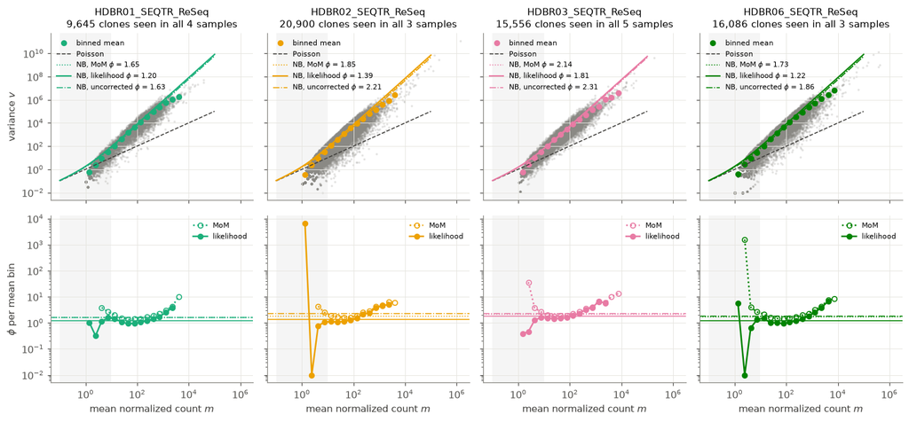

|  | phi MoM complete-case | phi MoM all (≥2 det.) |
| --- | --- | --- |
| HDBR01_SEQTR_ReSeq | 1.65 | 0.56 |
| HDBR02_SEQTR_ReSeq | 1.85 | 1.00 |
| HDBR03_SEQTR_ReSeq | 2.14 | 0.59 |
| HDBR06_SEQTR_ReSeq | 1.73 | 0.86 |

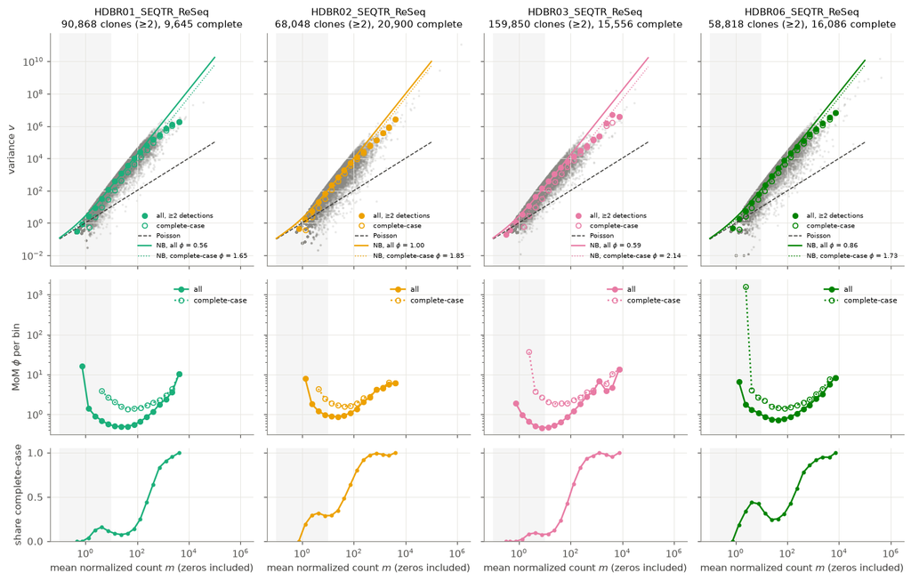

One more takeaway from the figure above is that the dispersion varies with frequency. More specifically, it increases with frequency, so more abundant clones are less noisier than less abundant ones.

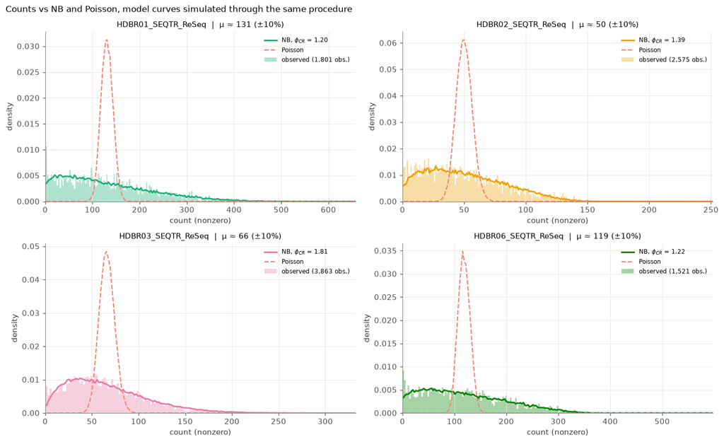

# 1.6 Dropout rate

One important finding from the sections above is the high prevalence of dropouts in the data. Having decided that we will model the count distribution using a Negative Binomial model, in the below we asses whether the model is able to correctly predict the number of dropouts of the data.

For each sample $t$, we compute the mean frequency of all clonotypes leaving out said sample, and then compute the expected count $\mu_{c,t}$ the clonotypes should have at sample $t$ acording to the other donor samples. With this expected value, we can compute the probability of a zero at the predicted count $P(0) = \left(\frac{\phi}{\phi+\mu_{c,t}}\right)^{\phi}$ and compare it against the actuall observation of the data. To avoid possible bias at lower count clones, we perform the test on clones with total mean frequency $\mu>100$ and $\mu>1000$.

For this study, we use the frequency-trended $\phi$ estimated using the corrected NB likelihood estimates from above. Altough we mentioned that they are not statistically validated, the estimation is close enough to the proper implementation in the pipeline so that big discrepancies between predictions and observations can be used to qualitatively motivate the need for corrections to the model.

What we observe below is that the data contains way more 0s than what the models expect.

```
μ ≥ 100:
```

| patient | clone_samples | observed | expected_trend | expected_const | obs / exp trend | obs / exp const |
| --- | --- | --- | --- | --- | --- | --- |
| HDBR01_SEQTR_ReSeq | 38093 | 14594 | 139.198 | 89.143 | 104.844 | 163.714 |
| HDBR02_SEQTR_ReSeq | 12785 | 1566 | 8.463 | 14.653 | 185.035 | 106.874 |
| HDBR03_SEQTR_ReSeq | 30271 | 5172 | 8.286 | 8.439 | 624.172 | 612.844 |
| HDBR06_SEQTR_ReSeq | 19790 | 5326 | 56.770 | 36.605 | 93.817 | 145.498 |

```
μ ≥ 1000:
```

| patient | clone_samples | observed | expected_trend | expected_const | obs / exp trend | obs / exp const |
| --- | --- | --- | --- | --- | --- | --- |
| HDBR01_SEQTR_ReSeq | 1476 | 106 | 0.004 | 0.275 | 2.808513e+04 | 384.991 |
| HDBR02_SEQTR_ReSeq | 838 | 8 | 0.000 | 0.038 | 4.300118e+08 | 208.325 |
| HDBR03_SEQTR_ReSeq | 1473 | 20 | 0.000 | 0.006 | 2.476884e+08 | 3128.159 |
| HDBR06_SEQTR_ReSeq | 1630 | 79 | 0.000 | 0.238 | 2.422046e+05 | 332.619 |

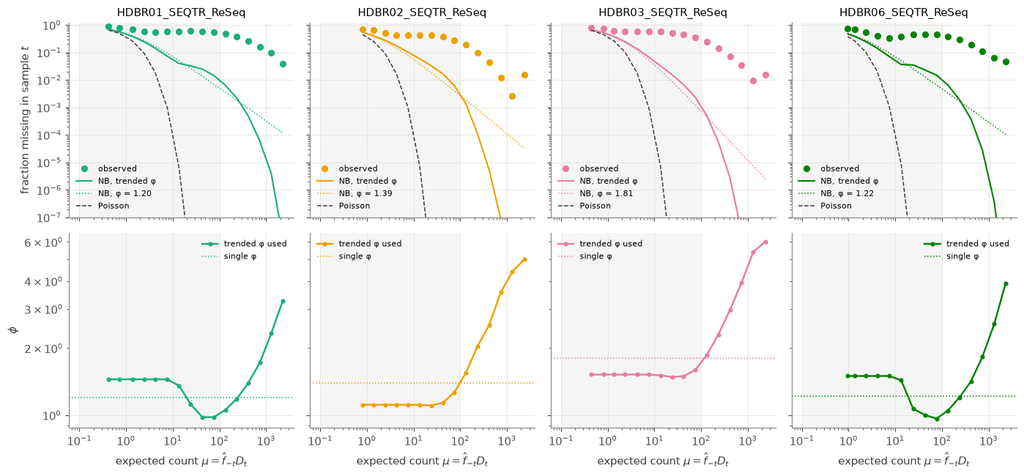

The next step is to investigaate whether this phenomena is strictly restricted to 0s or if it is a low count behaviour in general. First, in the table below how many clonotypes have less than 2 avergae counts, and how much of the total read count they make up.

| patient | day | clonotypes | % clones c=1 | % clones c=2 | % clones c≤2 | % reads in c≤2 |
| --- | --- | --- | --- | --- | --- | --- |
| HDBR01_SEQTR_ReSeq | 0 | 420234 | 53.47 | 9.72 | 63.19 | 2.95 |
|  | 21 | 545909 | 51.51 | 9.63 | 61.13 | 2.94 |
|  | 42 | 659852 | 57.98 | 10.74 | 68.72 | 2.42 |
|  | 126 | 548974 | 54.77 | 10.44 | 65.21 | 2.94 |
| HDBR02_SEQTR_ReSeq | 0 | 288817 | 49.15 | 9.69 | 58.84 | 3.58 |
|  | 48 | 219855 | 53.73 | 10.00 | 63.72 | 1.81 |
|  | 71 | 352926 | 48.57 | 10.65 | 59.22 | 3.60 |
| HDBR03_SEQTR_ReSeq | 0 | 311643 | 54.65 | 10.32 | 64.97 | 2.17 |
|  | 21 | 452593 | 45.14 | 10.39 | 55.53 | 5.86 |
|  | 35 | 349819 | 53.48 | 8.87 | 62.35 | 3.78 |
|  | 66 | 356969 | 47.84 | 8.98 | 56.81 | 4.51 |
|  | 84 | 396574 | 55.64 | 10.84 | 66.48 | 5.47 |
| HDBR06_SEQTR_ReSeq | 0 | 208284 | 57.69 | 10.69 | 68.37 | 1.52 |
|  | 82 | 305060 | 54.83 | 10.79 | 65.61 | 2.00 |
|  | 105 | 438383 | 56.76 | 11.62 | 68.38 | 3.17 |

| patient | day | clonotypes | % clones c=1 | % clones c=2 | % clones c≤2 | % reads in c≤2 |
| --- | --- | --- | --- | --- | --- | --- |
| BR032 | 0 | 521158 | 55.70 | 10.36 | 66.05 | 10.74 |
|  | 26 | 621612 | 56.92 | 13.20 | 70.12 | 8.50 |
|  | 47 | 773156 | 55.72 | 12.74 | 68.46 | 11.60 |
|  | 110 | 517387 | 56.65 | 12.00 | 68.65 | 7.05 |
|  | 187 | 419917 | 57.94 | 13.47 | 71.41 | 5.94 |
|  | 425 | 444650 | 54.00 | 8.85 | 62.85 | 3.36 |
| BR037 | 0 | 505732 | 59.12 | 13.58 | 72.70 | 7.94 |
|  | 28 | 438604 | 56.44 | 10.78 | 67.22 | 9.70 |
|  | 119 | 347362 | 58.19 | 13.76 | 71.95 | 6.22 |
|  | 189 | 334202 | 57.20 | 14.58 | 71.79 | 4.29 |
|  | 218 | 511287 | 59.20 | 14.34 | 73.54 | 7.31 |
|  | 364 | 385337 | 60.20 | 11.23 | 71.43 | 3.58 |
| BR046 | 0 | 505155 | 58.30 | 13.68 | 71.97 | 6.88 |
|  | 18 | 466970 | 58.59 | 11.18 | 69.76 | 5.03 |
|  | 120 | 309220 | 57.97 | 13.38 | 71.35 | 3.42 |
|  | 194 | 421219 | 59.24 | 12.45 | 71.69 | 5.16 |
|  | 222 | 278862 | 55.72 | 10.79 | 66.51 | 4.13 |
|  | 372 | 259525 | 59.35 | 11.56 | 70.91 | 3.25 |
| BR048 | 0 | 525531 | 57.80 | 12.15 | 69.95 | 7.97 |
|  | 22 | 367334 | 59.16 | 13.01 | 72.17 | 5.08 |
|  | 112 | 518991 | 59.72 | 13.26 | 72.98 | 6.81 |
|  | 161 | 624261 | 59.68 | 12.17 | 71.85 | 6.79 |
|  | 212 | 585858 | 57.92 | 12.15 | 70.07 | 7.24 |
|  | 371 | 546375 | 58.85 | 12.57 | 71.42 | 7.41 |
| BR052 | 0 | 1335897 | 56.90 | 13.05 | 69.95 | 9.46 |
|  | 18 | 342892 | 59.25 | 13.83 | 73.08 | 5.81 |
|  | 87 | 408220 | 59.13 | 11.78 | 70.91 | 6.18 |
|  | 164 | 17836 | 74.76 | 8.73 | 83.49 | 0.60 |
|  | 192 | 36788 | 64.61 | 12.40 | 77.02 | 1.06 |
|  | 348 | 369035 | 59.27 | 14.70 | 73.97 | 5.65 |
| BR054 | 0 | 391708 | 55.96 | 10.58 | 66.54 | 5.42 |
|  | 19 | 841771 | 53.66 | 12.00 | 65.66 | 5.57 |
|  | 68 | 536366 | 57.86 | 12.78 | 70.64 | 8.32 |
|  | 141 | 103473 | 58.62 | 12.30 | 70.92 | 2.88 |
|  | 187 | 376184 | 58.26 | 12.18 | 70.44 | 7.10 |
|  | 327 | 178832 | 58.01 | 14.44 | 72.44 | 3.44 |
| NOUS_18_SEQTR | 0 | 123263 | 56.90 | 8.68 | 65.58 | 1.87 |
|  | 24 | 168191 | 47.64 | 8.63 | 56.26 | 2.52 |
|  | 47 | 201316 | 51.21 | 9.10 | 60.31 | 2.89 |
|  | 54 | 190982 | 56.72 | 9.48 | 66.20 | 2.53 |
|  | 77 | 170103 | 56.93 | 9.41 | 66.34 | 2.62 |
|  | 96 | 124794 | 48.01 | 7.74 | 55.75 | 1.68 |
|  | 194 | 229950 | 52.94 | 9.60 | 62.53 | 3.98 |

| count in this sample → % seen in another sample patient | 1 | 2 | 3–5 | 6–10 | >10 |
| --- | --- | --- | --- | --- | --- |
| HDBR01_SEQTR_ReSeq | 4.9 | 10.4 | 15.0 | 16.4 | 19.5 |
| HDBR02_SEQTR_ReSeq | 8.8 | 19.7 | 24.9 | 24.4 | 34.1 |
| HDBR03_SEQTR_ReSeq | 12.6 | 25.6 | 31.2 | 30.4 | 41.1 |
| HDBR06_SEQTR_ReSeq | 7.1 | 15.4 | 23.8 | 25.7 | 26.4 |

A few conclusions can be drawn from the tables above:

In the figure below, we repeat the same dropout test from abowe but for $k=1,2,3$ observations. What we find is that, although there are also discrepancies between observatios and prefictions for $k=1,2,3$, none of them are as significant as the 0 case.

| patient | k=0 expected_trend | k=0 obs/exp | k=0 observed | k=1 expected_trend | k=1 obs/exp | k=1 observed | k=2 expected_trend | k=2 obs/exp | k=2 observed | k=3 expected_trend | k=3 obs/exp | k=3 observed |
| --- | --- | --- | --- | --- | --- | --- | --- | --- | --- | --- | --- | --- |
| HDBR01_SEQTR_ReSeq | 139.20 | 104.84 | 14594 | 146.68 | 1.62 | 237 | 150.56 | 1.12 | 169 | 153.03 | 1.11 | 170 |
| HDBR02_SEQTR_ReSeq | 8.46 | 185.03 | 1566 | 12.20 | 4.02 | 49 | 14.93 | 4.09 | 61 | 17.15 | 2.97 | 51 |
| HDBR03_SEQTR_ReSeq | 8.29 | 624.17 | 5172 | 14.08 | 8.81 | 124 | 19.05 | 5.25 | 100 | 23.54 | 3.61 | 85 |
| HDBR06_SEQTR_ReSeq | 56.77 | 93.82 | 5326 | 60.57 | 1.73 | 105 | 62.59 | 1.42 | 89 | 63.91 | 1.19 | 76 |

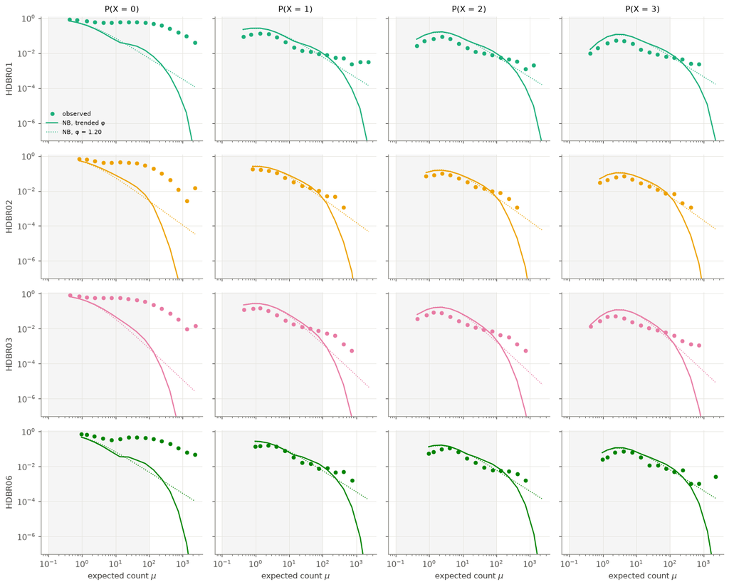

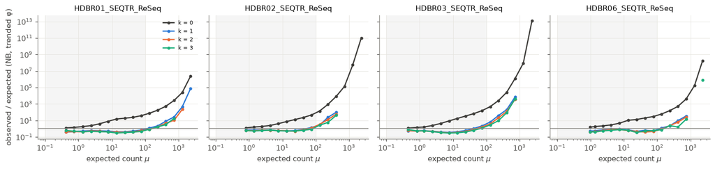

**What do these finding mean for the model?** It means that the data is zero-inflated. This is, there is a external (to this point unknown) mechanism that produces more zeros than what a regular NB model predicts. The most suitable options, which will me explored in the next notebook, are a Hurdle model or a Zero-Inflated negaaative binomial model.

## 1.6.1 Does per sample variabilty remove the zero-inflation?

One last question to answer before moving on to the next section is whether or not biological variability across samples may bias the computation of the expected 0. In the following cells, we will fit a per-sample dispersion (using the corrected NB model) and repeat the expected vs observed droput test using said estimated.

| patient | day | D_t (M) | L_t (M) | clones | φ_t | φ pooled | φ_t / pooled | LR | df | p | converged |
| --- | --- | --- | --- | --- | --- | --- | --- | --- | --- | --- | --- |
| HDBR01_SEQTR_ReSeq | 0 | 10.380 | 11.193 | 7003 | 1.127 | 1.210 | 0.931 | 88.908 | 3 | 0.0 | True |
|  | 21 | 13.135 | 13.177 | 7003 | 1.441 | 1.210 | 1.190 | 88.908 | 3 | 0.0 | True |
|  | 42 | 21.685 | 18.723 | 7003 | 1.192 | 1.210 | 0.985 | 88.908 | 3 | 0.0 | True |
|  | 126 | 14.117 | 15.116 | 7003 | 1.127 | 1.210 | 0.931 | 88.908 | 3 | 0.0 | True |
| HDBR02_SEQTR_ReSeq | 0 | 5.523 | 5.655 | 12815 | 2.175 | 1.420 | 1.531 | 1409.344 | 2 | 0.0 | True |
|  | 48 | 8.975 | 9.722 | 12815 | 0.798 | 1.420 | 0.562 | 1409.344 | 2 | 0.0 | True |
|  | 71 | 6.841 | 6.168 | 12815 | 2.201 | 1.420 | 1.550 | 1409.344 | 2 | 0.0 | True |
| HDBR03_SEQTR_ReSeq | 0 | 10.821 | 10.263 | 11510 | 1.020 | 1.806 | 0.565 | 2288.963 | 4 | 0.0 | True |
|  | 21 | 5.093 | 5.037 | 11510 | 2.843 | 1.806 | 1.575 | 2288.963 | 4 | 0.0 | True |
|  | 35 | 6.585 | 6.733 | 11510 | 1.920 | 1.806 | 1.063 | 2288.963 | 4 | 0.0 | True |
|  | 66 | 5.205 | 5.373 | 11510 | 2.460 | 1.806 | 1.362 | 2288.963 | 4 | 0.0 | True |
|  | 84 | 5.611 | 5.667 | 11510 | 2.004 | 1.806 | 1.110 | 2288.963 | 4 | 0.0 | True |
| HDBR06_SEQTR_ReSeq | 0 | 10.825 | 11.055 | 9050 | 1.009 | 1.222 | 0.825 | 148.481 | 2 | 0.0 | True |
|  | 82 | 11.651 | 11.018 | 9050 | 1.295 | 1.222 | 1.060 | 148.481 | 2 | 0.0 | True |
|  | 105 | 11.059 | 11.451 | 9050 | 1.437 | 1.222 | 1.176 | 148.481 | 2 | 0.0 | True |

```
Spearman ρ (φ_t, L_t/N_t), all samples: -0.92  (p = 1.42e-06, n = 15)
```

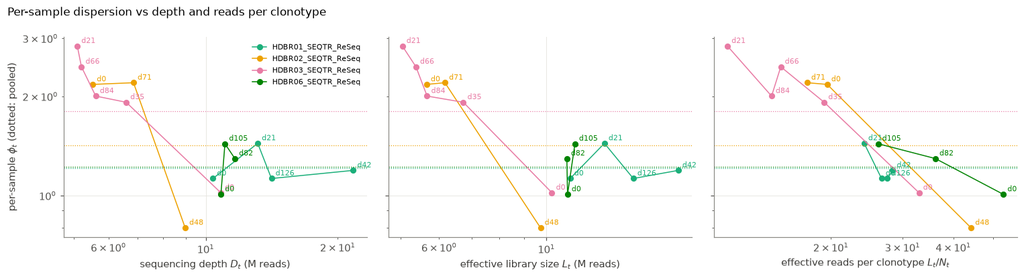

One quick remark is that the dispersion seems to follow a shared decreasing trend with respect to the effective reads per clontype which is shared across donors. Altough we do not model this trend in the actual pipeline, it could be taken into consideration.

| patient | day | L_t (M) | φ_t | n (μ ≥ 100) | % missing | % expected (φ_t) | obs / exp (φ_t) | obs / exp (pooled φ) | P(0) at μ=100 | slope b | se b |
| --- | --- | --- | --- | --- | --- | --- | --- | --- | --- | --- | --- |
| HDBR01_SEQTR_ReSeq | 0 | 11.193 | 1.127 | 7629 | 36.715 | 0.334 | 109.846 | 152.254 | 0.537 | -1.032 | 0.049 |
|  | 21 | 13.177 | 1.441 | 8598 | 30.402 | 0.097 | 314.726 | 131.711 | 0.473 | -1.034 | 0.048 |
|  | 42 | 18.723 | 1.192 | 11992 | 43.487 | 0.238 | 183.089 | 196.344 | 0.629 | -1.006 | 0.034 |
|  | 126 | 15.116 | 1.127 | 9954 | 38.196 | 0.310 | 123.023 | 171.016 | 0.551 | -0.893 | 0.038 |
| HDBR02_SEQTR_ReSeq | 0 | 5.655 | 2.175 | 3478 | 9.373 | 0.008 | 1151.385 | 88.567 | 0.188 | -1.352 | 0.142 |
|  | 48 | 9.722 | 0.798 | 5715 | 20.420 | 1.217 | 16.784 | 202.316 | 0.385 | -1.316 | 0.073 |
|  | 71 | 6.168 | 2.201 | 3684 | 6.270 | 0.007 | 856.050 | 60.267 | 0.134 | -1.421 | 0.171 |
| HDBR03_SEQTR_ReSeq | 0 | 10.263 | 1.020 | 9390 | 26.645 | 0.499 | 53.401 | 971.271 | 0.458 | -1.299 | 0.052 |
|  | 21 | 5.037 | 2.843 | 4458 | 5.541 | 0.001 | 4767.913 | 192.636 | 0.097 | -1.046 | 0.152 |
|  | 35 | 6.733 | 1.920 | 6305 | 16.701 | 0.019 | 883.214 | 603.484 | 0.290 | -1.132 | 0.075 |
|  | 66 | 5.373 | 2.460 | 4844 | 9.538 | 0.004 | 2706.729 | 335.741 | 0.186 | -1.370 | 0.125 |
|  | 84 | 5.667 | 2.004 | 5146 | 13.894 | 0.015 | 955.773 | 494.180 | 0.275 | -1.498 | 0.105 |
| HDBR06_SEQTR_ReSeq | 0 | 11.055 | 1.009 | 7349 | 35.515 | 0.457 | 77.778 | 184.718 | 0.561 | -0.964 | 0.042 |
|  | 82 | 11.018 | 1.295 | 6463 | 25.468 | 0.137 | 185.709 | 139.273 | 0.420 | -0.832 | 0.047 |
|  | 105 | 11.451 | 1.437 | 6002 | 17.661 | 0.074 | 237.258 | 102.863 | 0.318 | -0.825 | 0.055 |

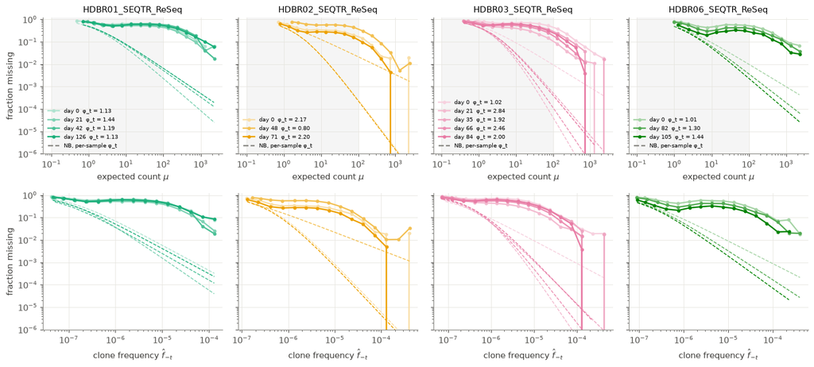

As can be seen from the figures, the underprediction of 0s stays high and consistent across samples, which leads us to mantaining the claim that the data is zero-inflated.

# 1.7 UMIs vs Counts

The data provided also contains collapsed UMI counts, which could alternatively be used to model the clonotypes. The providers advised against using UMIs. Neverthenless, we want to asses what the relationship between UMIs and raw counts is.

|  | rows | Spearman ρ (reads, UMIs) | reads per UMI (overall) | % rows UMI = 0 | % rows reads = UMIs |
| --- | --- | --- | --- | --- | --- |
| HDBR01_SEQTR_ReSeq | 2174969.0 | 0.942 | 2.105 | 0.0 | 63.505 |
| HDBR02_SEQTR_ReSeq | 861598.0 | 0.966 | 1.873 | 0.0 | 64.976 |
| HDBR03_SEQTR_ReSeq | 1867598.0 | 0.958 | 1.684 | 0.0 | 62.767 |
| HDBR06_SEQTR_ReSeq | 951727.0 | 0.932 | 2.634 | 0.0 | 66.324 |

| patient | clones | φ reads | φ UMIs | φ UMIs / φ reads | ratio 95% CI |
| --- | --- | --- | --- | --- | --- |
| HDBR01_SEQTR_ReSeq | 7009 | 1.20 | 1.24 | 1.03 | 1.03 – 1.04 |
| HDBR02_SEQTR_ReSeq | 12817 | 1.39 | 1.53 | 1.10 | 1.09 – 1.10 |
| HDBR03_SEQTR_ReSeq | 11519 | 1.81 | 2.00 | 1.11 | 1.10 – 1.11 |
| HDBR06_SEQTR_ReSeq | 9072 | 1.22 | 1.29 | 1.05 | 1.04 – 1.06 |

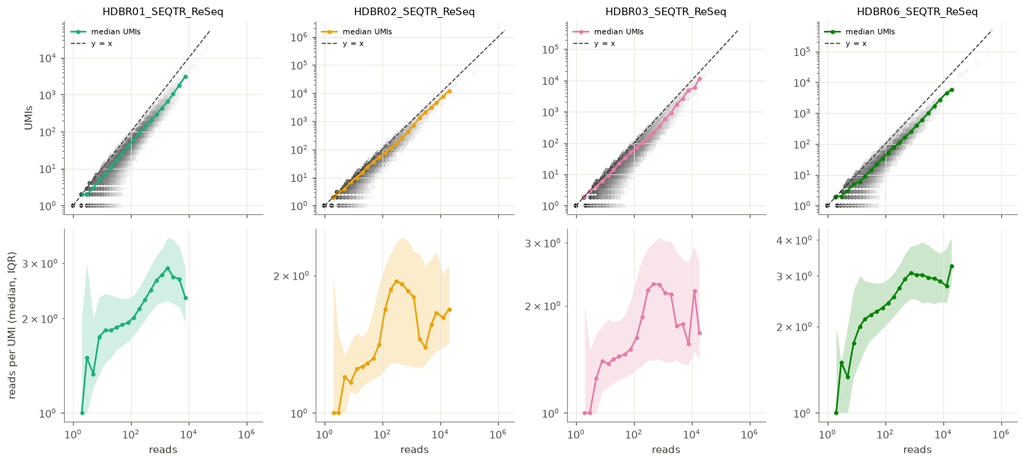

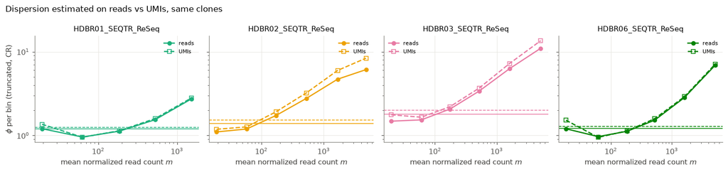

# 1.8 A deep dive into sample quality

In sections above, we proposed a QC check to determine which samples/libraries are usable and which should be discarded. In the QC pass, we discarded one donor library and two patient libraries, with some few patient libraries being flagged as suspicious. During the validation and testing of the pipeline, we further notices suspicious behavior of the flagged samples, which upon further investigation lead to the writing of this section: a more detailed look into the library compositions.

We will start by showing the overlap between the top 500 most frequent clones in each sample for both donors and patients. The overlap has to be done usin the exact CDR + V + J sequence of each clonotype, so this section will use the **non-anonimyzed data** and will not run if said data is not available.

The overlap between samples can be seen in the heatmap below, where we have also highlighted the samples dropped by the previous QC.

```
read patient  BR032
read patient  BR037
read patient  BR046
read patient  BR048
read patient  BR052
read patient  BR054
read patient  NOUS_18
read donor    HD106
read donor    HD197
read donor    HDBR01
read donor    HDBR02
read donor    HDBR03
read donor    HDBR06
Reference levels (two-way overlap of the 500 largest clonotypes, samples not foreign to their label):
  same person      : median 0.73 (lowest 0.10)
  different people : median 0.003, 99 % below 0.08
```

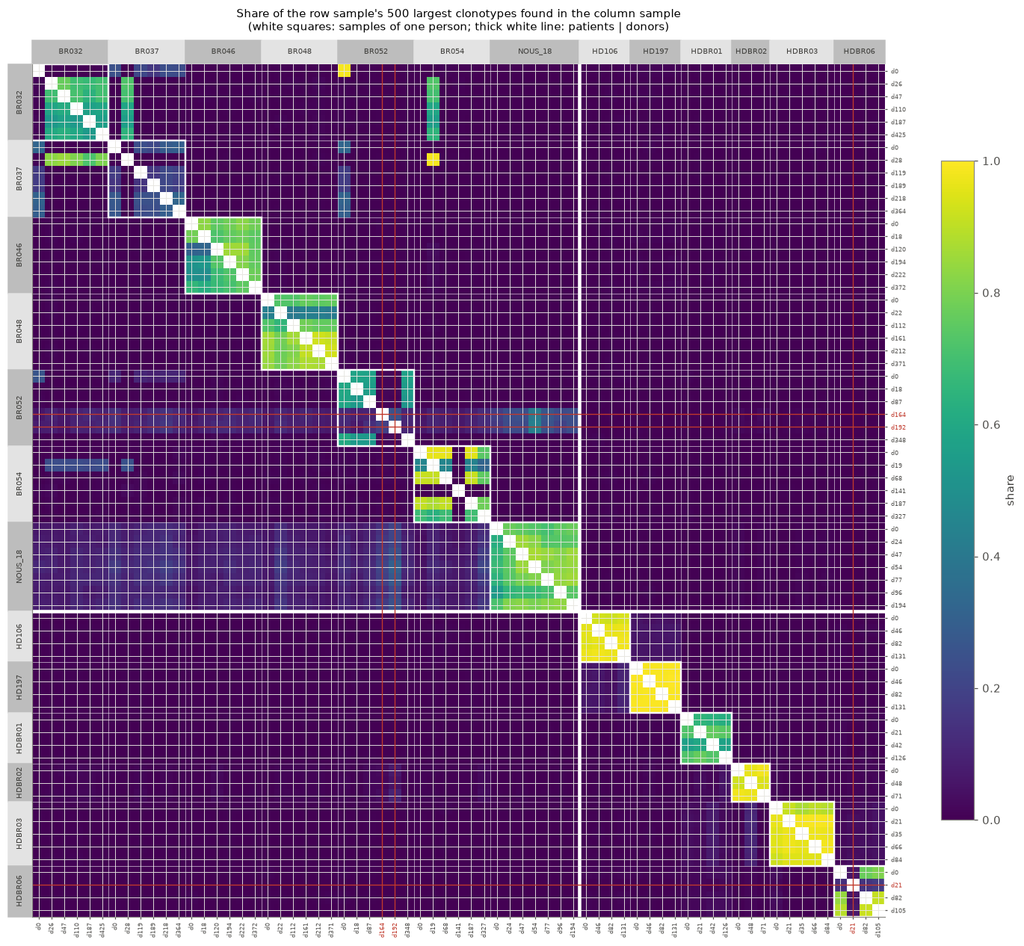

Swap BR032 d0 ↔ BR037 d28: share of the 500 largest clonotypes shared between samples (two-way). Same person: usually ~74%; different people: below 8%.

| patient | sample | with own patient's other samples (median) | with BR032 d0 (labelled BR032) | with BR037 d28 (labelled BR037) |
| --- | --- | --- | --- | --- |
| BR032 | BR032 d0 | 1% | — | 1% |
|  | BR032 d26 | 65% | 0% | 78% |
|  | BR032 d47 | 66% | 1% | 78% |
|  | BR032 d110 | 62% | 0% | 70% |
|  | BR032 d187 | 58% | 1% | 64% |
|  | BR032 d425 | 62% | 1% | 73% |
| BR037 | BR037 d0 | 24% | 29% | 0% |
|  | BR037 d28 | 0% | 1% | — |
|  | BR037 d119 | 21% | 19% | 0% |
|  | BR037 d189 | 20% | 17% | 0% |
|  | BR037 d218 | 26% | 28% | 0% |
|  | BR037 d364 | 25% | 27% | 0% |

BR032's other samples share 73% of their largest clonotypes with BR037 d28 (their usual level among themselves: 62%) and 1% with BR032 d0.

**Conclusion**: the sample labelled BR037 d28 comes from BR032, and the sample labelled BR032 d0 comes from BR037 and the two samples were swapped.

Samples that passed QC but behave suspiciously. Overlap = share of the 500 largest clonotypes shared with the patient's other samples (two-way). Different people: below 8%.

| sample | finding | overlap with own other samples | reads (M) | usual reads (M) | clonotypes | usual clonotypes | top-500 share of reads | usual share | strongest signal from another person |
| --- | --- | --- | --- | --- | --- | --- | --- | --- | --- |
| BR052 d0 | Contains material from another sample | 59% | 11.7 | 5.6 | 1,335,897 | 388,628 | 9% | 13% | 99% of the top 500 of BR032 d0 (= BR037's sample) |
| BR054 d141 | Failed library | 0% | 3.0 | 5.4 | 103,473 | 391,708 | 72% | 21% | 7% of the top 500 of NOUS_18 d54 |
| BR054 d19 | Contains material from another sample | 67% | 11.7 | 5.4 | 841,771 | 391,708 | 18% | 21% | 99% of the top 500 of BR037 d28 (= BR032's sample) |

BR052 d0: clonotypes of BR032 d0 (= BR037's sample) in BR052's samples. Same person: usually ~74%; different people: below 8%.

| sample | reads (M) | with own patient's other samples (median) | BR032 d0's top 500 found here | top 500 found in BR032 d0 |
| --- | --- | --- | --- | --- |
| BR052 d0 | 11.7 | 59% | 99% | 26% |
| BR052 d18 | 5.1 | 55% | 0% | 0% |
| BR052 d87 | 5.5 | 55% | 1% | 1% |
| BR052 d348 | 5.8 | 54% | 0% | 0% |

BR054 d19: clonotypes of BR037 d28 (= BR032's sample) in BR054's samples. Same person: usually ~74%; different people: below 8%.

| sample | reads (M) | with own patient's other samples (median) | BR037 d28's top 500 found here | top 500 found in BR037 d28 |
| --- | --- | --- | --- | --- |
| BR054 d0 | 5.6 | 82% | 0% | 0% |
| BR054 d19 | 11.7 | 67% | 99% | 25% |
| BR054 d68 | 5.4 | 82% | 1% | 1% |
| BR054 d141 | 3.0 | 0% | 1% | 2% |
| BR054 d187 | 4.4 | 82% | 0% | 0% |
| BR054 d327 | 4.5 | 72% | 0% | 0% |

- BR052 d0 is otherwise consistent with BR052 (overlap with its other samples 59%, usual 56%), but 99% of the 500 largest clonotypes of BR032 d0 (= BR037's sample) are also found in it, against at most 1% in BR052's other samples. It also has 11.7 M reads, about 2.1x BR052's usual 5.6 M
- BR054 d19 is otherwise consistent with BR054 (overlap with its other samples 67%, usual 72%), but 99% of the 500 largest clonotypes of BR037 d28 (= BR032's sample) are also found in it, against at most 1% in BR054's other samples. It also has 11.7 M reads, about 2.2x BR054's usual 5.4 M.

**Conclusion**: Both of these samples were contaminated with material from another sample. The fact that the two samples that produce the contamination are the sames ones that are swapped supports this finding.

BR054: library and overlap of each sample (BR054 d141 in red; BR054 d19 in orange, see the previous table). Same person: usually ~74%; different people: below 8%.

| sample | reads (M) | clonotypes | largest clonotype, share of reads | top-500 share of reads | overlap with own other samples (median) | closest sample in the dataset (other person) | overlap with it | sample QC |
| --- | --- | --- | --- | --- | --- | --- | --- | --- |
| BR054 d0 | 5.6 | 391,708 | 3% | 22% | 82% | BR052 d192 | 4% | kept |
| BR054 d19 | 11.7 | 841,771 | 2% | 18% | 67% | BR037 d28 | 62% | kept |
| BR054 d68 | 5.4 | 536,366 | 2% | 20% | 82% | BR052 d192 | 5% | kept |
| BR054 d141 | 3.0 | 103,473 | 19% | 72% | 0% | BR052 d192 | 3% | kept |
| BR054 d187 | 4.4 | 376,184 | 2% | 21% | 82% | BR052 d164 | 5% | kept |
| BR054 d327 | 4.5 | 178,832 | 3% | 28% | 72% | NOUS_18 d54 | 11% | kept |

BR054 d141 shares 0% of its 500 largest clonotypes with BR054's other samples (usual within BR054: 72%) and at most 3% with any sample of another person (closest: BR052 d192), so it matches no one in this dataset. Its library is also atypical: 103,473 clonotypes (usual 391,708), the largest clonotype holds 19% of reads (usual 2%) and the 500 largest hold 72% (usual 21%).

**Conclusion**: It comes from a person outside this dataset or is a failed library.

**Summary of the libraries**

Patients

| sample | QC | specific analysis |
| --- | --- | --- |
| BR032 d0 | OK | swapped |
| BR032 d26 | OK | OK |
| BR032 d47 | OK | OK |
| BR032 d110 | OK | OK |
| BR032 d187 | OK | OK |
| BR032 d425 | OK | OK |
| BR037 d0 | OK | OK |
| BR037 d28 | flagged | swapped |
| BR037 d119 | OK | OK |
| BR037 d189 | OK | OK |
| BR037 d218 | OK | OK |
| BR037 d364 | OK | OK |
| BR046 d0 | OK | OK |
| BR046 d18 | OK | OK |
| BR046 d120 | flagged | OK |
| BR046 d194 | OK | OK |
| BR046 d222 | OK | OK |
| BR046 d372 | OK | OK |
| BR048 d0 | OK | OK |
| BR048 d22 | OK | OK |
| BR048 d112 | OK | OK |
| BR048 d161 | OK | OK |
| BR048 d212 | OK | OK |
| BR048 d371 | OK | OK |
| BR052 d0 | OK | flagged |
| BR052 d18 | OK | OK |
| BR052 d87 | OK | OK |
| BR052 d164 | dropped | dropped |
| BR052 d192 | dropped | dropped |
| BR052 d348 | OK | OK |
| BR054 d0 | OK | OK |
| BR054 d19 | OK | flagged |
| BR054 d68 | OK | OK |
| BR054 d141 | flagged | dropped |
| BR054 d187 | OK | OK |
| BR054 d327 | OK | OK |
| NOUS_18 d0 | OK | OK |
| NOUS_18 d24 | OK | OK |
| NOUS_18 d47 | OK | OK |
| NOUS_18 d54 | OK | OK |
| NOUS_18 d77 | OK | OK |
| NOUS_18 d96 | OK | OK |
| NOUS_18 d194 | OK | OK |

Donors

| sample | QC | specific analysis |
| --- | --- | --- |
| HD106 d0 | OK | OK |
| HD106 d46 | OK | OK |
| HD106 d82 | OK | OK |
| HD106 d131 | OK | OK |
| HD197 d0 | OK | OK |
| HD197 d46 | OK | OK |
| HD197 d82 | OK | OK |
| HD197 d131 | OK | OK |
| HDBR01 d0 | OK | OK |
| HDBR01 d21 | OK | OK |
| HDBR01 d42 | OK | OK |
| HDBR01 d126 | OK | OK |
| HDBR02 d0 | OK | OK |
| HDBR02 d48 | OK | OK |
| HDBR02 d71 | OK | OK |
| HDBR03 d0 | OK | OK |
| HDBR03 d21 | OK | OK |
| HDBR03 d35 | OK | OK |
| HDBR03 d66 | OK | OK |
| HDBR03 d84 | OK | OK |
| HDBR06 d0 | OK | OK |
| HDBR06 d21 | dropped | OK |
| HDBR06 d82 | OK | OK |
| HDBR06 d105 | OK | OK |

[output not shown]